# Using strm with Census Data

```r
#load libraries:
#load strm
library(strm)
library(rmarkdown)
library(knitr)
#load package dependencies for the vignette
library(tidyr)
library(dplyr)
library(ggplot2)
library(broom)
library(patchwork)
library(purrr)
library(rgdal)
library(spdep)
```

`strm` is an `R` package that fits spatio-temporal regression model based on Chi & Zhu *Spatial Regression Models for the Social Sciences* (2019). The approach here fits a spatial error model while incorporating a temporally lagged response variable and temporally lagged explanatory variables.

This package builds on the `errorsarlm()` function from the `spatialreg` package.

This package is still under development. Please report bugs or constructive tips to issues [here](https://github.com/mkamenet3/strm/issues).

# Introduction

This data example will work through downloading census data using the `tidycensus` package, creating spatial weights, and then using `strm` to fit the spatio-temporal regression model. We will fit the same model using both the *long* and *wide* data formats.

In this example, we want to look at percent poverty as it relates to female employment rates at the Wisconsin county-level. We will use the American Community Survey (ACS) 5-year data. The variables we will extract are:

- `B17020_002` - Estimate: Total - Income in the past 12 months below poverty level
- `B17020_001` - Estimate: Total - Poverty Status in the past 12 months.
- `B23022_026` - Estimate: Total Female by Work Status by weeks worked in the past 12 months for the population 16-64 years old.
- `B23022_001` - Estimate: Total: status in the past 12 months by usual hours worked per week in the past 12 months by weeks worked in the past 12 months for the population 16-64 years old (Male and Female)

We first load in the dataset `wi_raw` that contains the raw 5-year estimates from two years: 2013-2017 and 2014-2018 ACS data at the county-level in Wisconsin using `data(wi_raw)`:

```r
data(wi_raw)
```

We first explore the raw Wisconsin data:

```r
class(wi_raw)
```

```
## [1] "sf"         "data.frame"
```

```r
names(wi_raw)
```

```
## [1] "GEOID"    "NAME"     "variable" "estimate" "moe"      "id"       "geometry"
```

```r
str(wi_raw)
```

```
## Classes 'sf' and 'data.frame':   576 obs. of  7 variables:
##  $ GEOID   : chr  "55043" "55043" "55043" "55043" ...
##  $ NAME    : chr  "Grant County, Wisconsin" "Grant County, Wisconsin" "Grant County, Wisconsin" "Grant County, Wisconsin" ...
##  $ variable: chr  "B17020_001" "B17020_002" "B23022_001" "B23022_026" ...
##  $ estimate: num  47928 7323 33826 15433 15929 ...
##  $ moe     : num  311 554 87 74 113 322 56 43 38 166 ...
##  $ id      : num  2017 2017 2017 2017 2017 ...
##  $ geometry:sfc_MULTIPOLYGON of length 576; first list element: List of 1
##   ..$ :List of 1
##   .. ..$ : num [1:423, 1:2] -91.2 -91.2 -91.1 -91.1 -91.1 ...
##   ..- attr(*, "class")= chr [1:3] "XY" "MULTIPOLYGON" "sfg"
##  - attr(*, "sf_column")= chr "geometry"
##  - attr(*, "agr")= Factor w/ 3 levels "constant","aggregate",..: NA NA NA NA NA NA
##   ..- attr(*, "names")= chr [1:6] "GEOID" "NAME" "variable" "estimate" ...
```

```r
head(wi_raw)
```

```
## Simple feature collection with 6 features and 6 fields
## geometry type:  MULTIPOLYGON
## dimension:      XY
## bbox:           xmin: -91.5518 ymin: 42.50706 xmax: -90.4258 ymax: 46.15791
## geographic CRS: NAD83
##   GEOID                     NAME   variable estimate moe   id
## 1 55043  Grant County, Wisconsin B17020_001    47928 311 2017
## 2 55043  Grant County, Wisconsin B17020_002     7323 554 2017
## 3 55043  Grant County, Wisconsin B23022_001    33826  87 2017
## 4 55043  Grant County, Wisconsin B23022_026    15433  74 2017
## 5 55113 Sawyer County, Wisconsin B17020_001    15929 113 2017
## 6 55113 Sawyer County, Wisconsin B17020_002     2825 322 2017
##                         geometry
## 1 MULTIPOLYGON (((-91.15681 4...
## 2 MULTIPOLYGON (((-91.15681 4...
## 3 MULTIPOLYGON (((-91.15681 4...
## 4 MULTIPOLYGON (((-91.15681 4...
## 5 MULTIPOLYGON (((-91.55095 4...
## 6 MULTIPOLYGON (((-91.55095 4...
```

Notice that `wi_raw` is of class `sf` and class `data.frame`

## Long-Form Data

### Exploratory (Spatial) Data Analysis

```r
wi <- wi_raw %>%
    dplyr::select(-moe) %>%
    spread(key = variable, value=estimate) %>%
    mutate(pov_prct = B17020_002/B17020_001,
           feemp_prct = B23022_026/B23022_001,
           year=id,
           logpov = log(pov_prct))
class(wi)
```

```
## [1] "sf"         "data.frame"
```

```r
str(wi)
```

```
## Classes 'sf' and 'data.frame':   144 obs. of  12 variables:
##  $ GEOID     : chr  "55001" "55001" "55003" "55003" ...
##  $ NAME      : chr  "Adams County, Wisconsin" "Adams County, Wisconsin" "Ashland County, Wisconsin" "Ashland County, Wisconsin" ...
##  $ id        : num  2017 2018 2017 2018 2017 ...
##  $ B17020_001: num  18962 18940 15164 15088 44510 ...
##  $ B17020_002: num  2457 2794 2215 2161 5138 ...
##  $ B23022_001: num  11964 11851 9889 9771 27406 ...
##  $ B23022_026: num  5303 5233 4899 4798 13333 ...
##  $ geometry  :sfc_MULTIPOLYGON of length 144; first list element: List of 1
##   ..$ :List of 1
##   .. ..$ : num [1:312, 1:2] -90 -90 -90 -90 -90 ...
##   ..- attr(*, "class")= chr [1:3] "XY" "MULTIPOLYGON" "sfg"
##  $ pov_prct  : num  0.13 0.148 0.146 0.143 0.115 ...
##  $ feemp_prct: num  0.443 0.442 0.495 0.491 0.486 ...
##  $ year      : num  2017 2018 2017 2018 2017 ...
##  $ logpov    : num  -2.04 -1.91 -1.92 -1.94 -2.16 ...
##  - attr(*, "sf_column")= chr "geometry"
##  - attr(*, "agr")= Factor w/ 3 levels "constant","aggregate",..: NA NA NA NA NA NA NA NA NA NA ...
##   ..- attr(*, "names")= chr [1:11] "GEOID" "NAME" "id" "B17020_001" ...
```

Let us explore the summary statistics by year for `pov_prct` using `summary()` and the `tapply()` function:

```r
summary(wi$pov_prct)
```

```
##    Min. 1st Qu.  Median    Mean 3rd Qu.    Max.
## 0.04454 0.09203 0.11502 0.11734 0.13586 0.35843
```

```r
tapply(wi$pov_prct, wi$year, summary)
```

```
## $`2017`
##    Min. 1st Qu.  Median    Mean 3rd Qu.    Max.
## 0.04760 0.09203 0.11505 0.11946 0.13736 0.35843
##
## $`2018`
##    Min. 1st Qu.  Median    Mean 3rd Qu.    Max.
## 0.04454 0.09300 0.11475 0.11521 0.13356 0.32647
```

We also the summary statistics by year for `feemp_prct`

```r
summary(wi$feemp_prct)
```

```
##    Min. 1st Qu.  Median    Mean 3rd Qu.    Max.
##  0.4416  0.4841  0.4900  0.4874  0.4955  0.5122
```

```r
tapply(wi$feemp_prct, wi$year, summary)
```

```
## $`2017`
##    Min. 1st Qu.  Median    Mean 3rd Qu.    Max.
##  0.4432  0.4840  0.4892  0.4874  0.4954  0.5117
##
## $`2018`
##    Min. 1st Qu.  Median    Mean 3rd Qu.    Max.
##  0.4416  0.4844  0.4906  0.4875  0.4958  0.5122
```

Finally, we look at correlation between percent poverty and percent female employment across all 2 years of ACS data:

```r
cor(wi$pov_prct,wi$feemp_prct)
```

```
## [1] -0.06646265
```

We next visually explore the data using the `geom_histogram()` and `geom_density()` geometries from the `ggplot2` package.

We first explore percent poverty (`pov_prct`) and the log-transformed percent poverty (`logpov`):

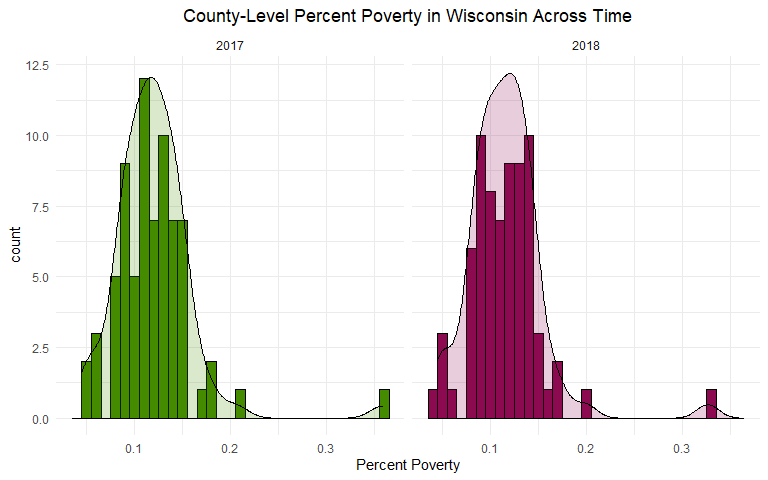

```r
ggplot(data=wi, aes(x=pov_prct)) +
    facet_grid(.~ year) +
    geom_histogram(binwidth=0.01,color="black", aes(fill=factor(year))) +
    geom_density(alpha=.2, aes(fill=factor(year))) +
    theme_minimal() +
    xlab("Percent Poverty") +
    labs(title="County-Level Percent Poverty in Wisconsin Across Time", fill="Year") +
    theme(plot.title = element_text(hjust = 0.5),
          legend.position = "none") +
    scale_fill_manual(values=c("chartreuse4", "deeppink4", "cornflowerblue","orange2","tomato3"))
```

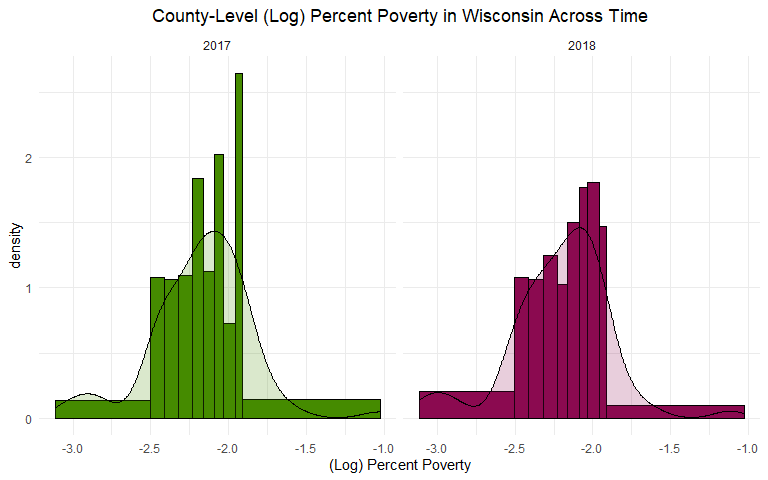

```r
breaks <- quantile(wi$logpov,seq(0,1,by=0.1))
ggplot(data=wi, aes(x=logpov)) +
    geom_histogram(aes(y =..density.., fill=factor(year)),color="black", breaks=breaks) +
    facet_grid(.~ year) +
    geom_density(alpha=.2, aes(fill=factor(year))) +
    theme_minimal() +
    xlab("(Log) Percent Poverty") +
    labs(title="County-Level (Log) Percent Poverty in Wisconsin Across Time", fill="Year") +
    theme(plot.title = element_text(hjust = 0.5),
          legend.position = "none") +
    scale_fill_manual(values=c("chartreuse4", "deeppink4", "cornflowerblue","orange2","tomato3"))
```

Recall that `wi` is of class `sf`. We can use the `geom_sf()` geometry to easily create maps of both `pov_prct` and `logpov`:

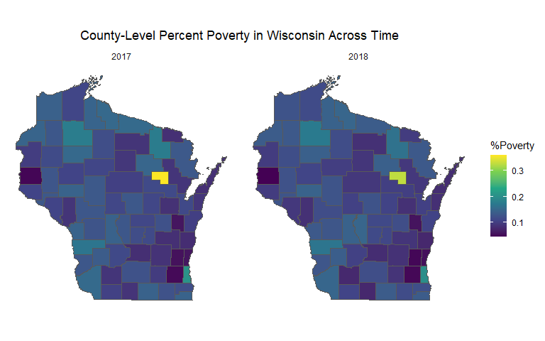

```r
ggplot(wi) +
    geom_sf(aes(fill = pov_prct)) +
    scale_fill_viridis_c() +
    coord_sf(datum = NA) +
    facet_grid(. ~ year) +
    theme_minimal()+
    theme(plot.title=element_text(hjust = 0.5)) +
    labs(title = "County-Level Percent Poverty in Wisconsin Across Time", fill="%Poverty")
```

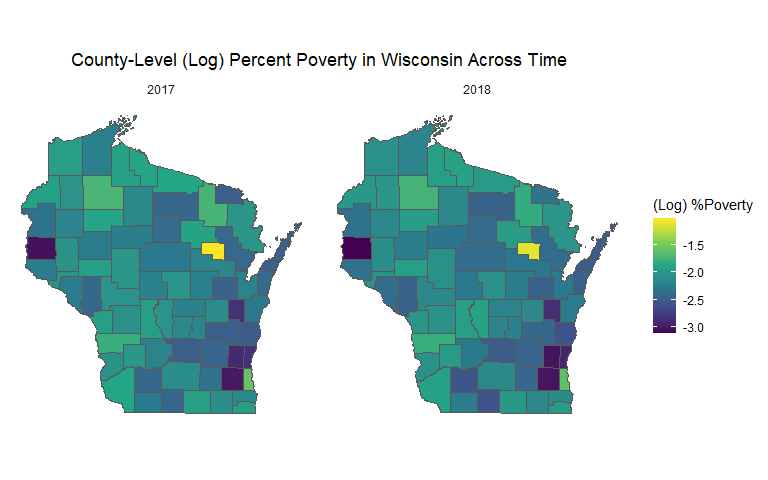

```r
ggplot(wi) +
    geom_sf(aes(fill = logpov)) +
    scale_fill_viridis_c() +
    coord_sf(datum = NA) +
    facet_grid(. ~ year) +
    theme_minimal()+
    theme(plot.title=element_text(hjust = 0.5)) +
    labs(title = "County-Level (Log) Percent Poverty in Wisconsin Across Time", fill="(Log) %Poverty")
```

Next we visually explore `feemp_prct`:

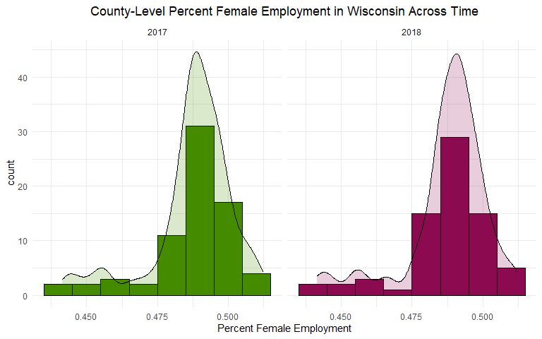

```r
ggplot(data=wi, aes(x=feemp_prct)) +
    facet_grid(.~ year) +
    geom_histogram(binwidth=0.01,color="black", aes(fill=factor(year))) +
    geom_density(alpha=.2, aes(fill=factor(year))) +
    theme_minimal() +
    xlab("Percent Female Employment") +
    labs(title="County-Level Percent Female Employment in Wisconsin Across Time", fill="Year") +
    theme(plot.title = element_text(hjust = 0.5),
          legend.position = "none") +
    scale_fill_manual(values=c("chartreuse4", "deeppink4", "cornflowerblue","orange2","tomato3"))
```

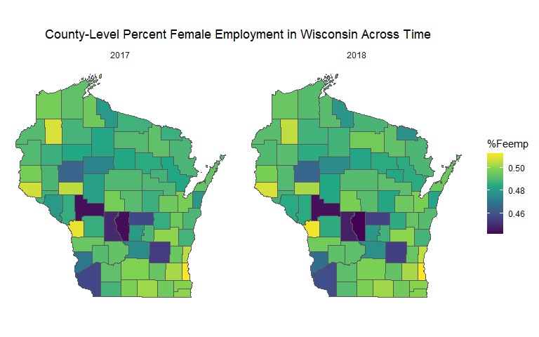

```r
ggplot(wi) +
    geom_sf(aes(fill = feemp_prct)) +
    scale_fill_viridis_c() +
    coord_sf(datum = NA) +
    facet_grid(. ~ year) +
    theme_minimal()+
    theme(plot.title=element_text(hjust = 0.5)) +
    labs(title = "County-Level Percent Female Employment in Wisconsin Across Time", fill="%Feemp")
```

### Create Neighbors

In order to apply the spatio-temporal model using `strm`, we need to first define county neighbors. We will define first-order contiguity-based neighborhood structure (Queen's adjacency) with row-standardized spatial weights.

We have 2 years of data, however the spatial dependence between counties remains the same. Therefore, we will select unique counties to create neighbors and spatial weights. Specifically, we will use the geometries from 2018 using `filter()` from `dplyr` and to simplify the data frame we will select just the `GEOID` and `NAME` variables using `select()` from `dplyr`:

```r
wi_uniq <- wi %>%
    dplyr::filter(year==2018) %>%
    dplyr::select(GEOID, NAME)
nrow(wi_uniq)
```

```
## [1] 72
```

```r
class(wi_uniq)
```

```
## [1] "sf"         "data.frame"
```

We now have 72 unique county geometries which correspond to the 72 counties in Wisconsin.

We next create the neighborhood structure using `poly2nb()` from the `spdep` package. We set the row names of `wi_uniq` dataframe to correspond to the county names and then use the argument `row.names=row.names(wi_uniq)` in `poly2nb()` so that we can easily identify each element of the neighborhood structure list with a county. Finally, we print the first 6 neighbors using `str(head(wi_nb))`:

```r
row.names(wi_uniq) <- wi_uniq$NAME
head(row.names(wi_uniq))
```

```
## [1] "Adams County, Wisconsin"    "Ashland County, Wisconsin"
## [3] "Barron County, Wisconsin"   "Bayfield County, Wisconsin"
## [5] "Brown County, Wisconsin"    "Buffalo County, Wisconsin"
```

```r
wi_nb <- poly2nb(wi_uniq, row.names=row.names(wi_uniq))
str(head(wi_nb))
```

```
## List of 6
##  $ : int [1:6] 11 29 39 50 70 72
##  $ : int [1:4] 4 26 51 58
##  $ : int [1:8] 7 9 17 49 55 56 58 66
##  $ : int [1:4] 2 16 58 66
##  $ : int [1:6] 8 31 36 43 45 59
##  $ : int [1:3] 18 47 62
```

Now that we have the neighborhood structure, we create the list of spatial weights using `nb2listw()` from the `spdep` package and print the class and first 6 elements of the spatial weights list:

```r
listw_w <- nb2listw(wi_nb, style = "W")
class(listw_w)
```

```
## [1] "listw" "nb"
```

```r
str(head(listw_w$weights))
```

```
## List of 6
##  $ : num [1:6] 0.167 0.167 0.167 0.167 0.167 ...
##  $ : num [1:4] 0.25 0.25 0.25 0.25
##  $ : num [1:8] 0.125 0.125 0.125 0.125 0.125 0.125 0.125 0.125
##  $ : num [1:4] 0.25 0.25 0.25 0.25
##  $ : num [1:6] 0.167 0.167 0.167 0.167 0.167 ...
##  $ : num [1:3] 0.333 0.333 0.333
```

Lastly, we can visualize these neighbors. We first extract the county polygons using `st_geometry()` from the `sf` package and save that as the object `county_geoms`. Next we find the county centroids using `st_centroid()` from `sf` on `county_geoms` and save that as the object `cntrd`. Lastly, we find the coordinates of the centroids using `st_coordinates()` on the `cntrd` object:

```r
county_geoms <- st_geometry(wi_uniq)
cntrd <- st_centroid(county_geoms)
coords <- st_coordinates(cntrd)
head(coords)
```

```
##           X        Y
## 1 -89.77039 43.96953
## 2 -90.67794 46.31608
## 3 -91.84831 45.42368
## 4 -91.20079 46.52376
## 5 -88.00373 44.45294
## 6 -91.75445 44.37983
```

We can visualize the county geometries, centroids, and neighborhood:

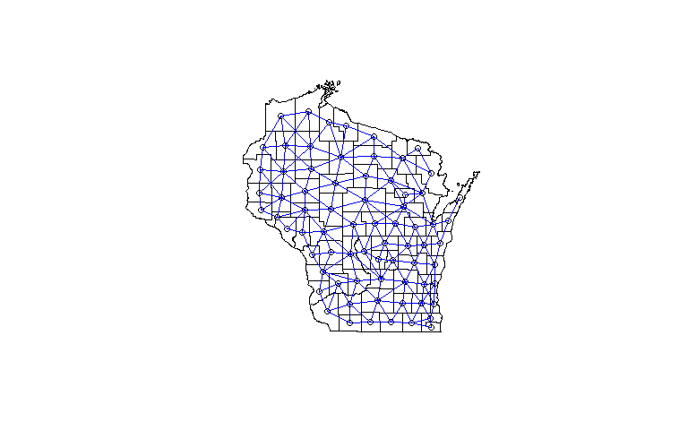

```r
plot(county_geoms)
plot(listw_w, coords, col="blue", add=TRUE)
```

### Using `strm`

We use the `strm()` function from the `strm` package. The first argument is the model formula. Given that the data is in *long* format, `strm` will create the lagged values for you as well as the lagged response in the right-hand side of the model. The next argument is `id`, which we set to "NAME" as each observation is taken at the county-level. We then specify the name of the data set (`data=wi`). We set the argument `listw=listw_w` to the row-standardized list of spatial weights. We set `time=2` because there are 2 time periods in the dataset. We set `wide=FALSE`, thereby specifying that the data is in *long* format. Lastly, we set the argument `returndf=TRUE` to return the modified dataframe along with the model output. The default to `returndf` is `FALSE` and `strm` will only return the model output summary.

```r
#create model formula
formula <-as.formula(logpov  ~ feemp_prct)
#use strm
out <- strm(formula, id="NAME", data=wi, listw = listw_w, time=2,wide=FALSE, returndf = TRUE)
```

```
## The spatio-temporal regression model fitted:
```

```
## logpov ~ feemp_prct + feemp_prct.Tlag1 + logpov.Tlag1
```

```r
#explore model summary output
summary(out$res)
```

```
##
## Call:spatialreg::errorsarlm(formula = modframe, listw = listw)
##
## Residuals:
##        Min         1Q     Median         3Q        Max
## -0.1164060 -0.0271689 -0.0052208  0.0303804  0.1135471
##
## Type: error
## Coefficients: (asymptotic standard errors)
##                   Estimate Std. Error z value  Pr(>|z|)
## (Intercept)       0.490041   0.194409  2.5207 0.0117131
## feemp_prct       -9.122181   2.765473 -3.2986 0.0009717
## feemp_prct.Tlag1  8.009282   2.792433  2.8682 0.0041280
## logpov.Tlag1      0.992349   0.018244 54.3924 < 2.2e-16
##
## Lambda: -0.35546, LR test value: 2.9886, p-value: 0.08385
## Asymptotic standard error: 0.18981
##     z-value: -1.8728, p-value: 0.061102
## Wald statistic: 3.5072, p-value: 0.061102
##
## Log likelihood: 110.748 for error model
## ML residual variance (sigma squared): 0.0026359, (sigma: 0.051341)
## Number of observations: 72
## Number of parameters estimated: 6
## AIC: -209.5, (AIC for lm: -208.51)
```

```r
#explore modified dataframe used in strm computation
summary(out$modframe)
```

```
##      logpov         feemp_prct     feemp_prct.Tlag1  logpov.Tlag1
##  Min.   :-3.111   Min.   :0.4416   Min.   :0.4432   Min.   :-3.045
##  1st Qu.:-2.375   1st Qu.:0.4844   1st Qu.:0.4840   1st Qu.:-2.386
##  Median :-2.165   Median :0.4906   Median :0.4892   Median :-2.162
##  Mean   :-2.212   Mean   :0.4875   Mean   :0.4874   Mean   :-2.175
##  3rd Qu.:-2.013   3rd Qu.:0.4958   3rd Qu.:0.4954   3rd Qu.:-1.985
##  Max.   :-1.119   Max.   :0.5122   Max.   :0.5117   Max.   :-1.026
```

We next explore the model diagnostics. We create a new dataframe called `out_df` using `cbind.data.frame()`, which has the model residuals, model standardized residuals, and fitted values.

```r
out_df <- cbind.data.frame(resids = out$res$residuals,
                           stdresids = out$res$residuals/sd(out$res$residuals),
                           fit = out$res$fitted.values)
```

Using the model residuals and fitted values, we create a QQ plot and (standardized) residuals vs. fitted plot, and show them both using the `+` operator from the `patchwork` R package:

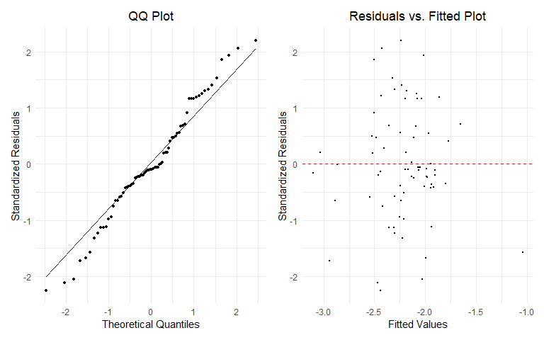

```r
#QQ Plot
p1 <- ggplot(out_df, aes(sample = stdresids)) +
    geom_qq(size = 1) +
    stat_qq_line() +
    theme_minimal() +
    xlab("Theoretical Quantiles") +
    ylab("Standardized Residuals") +
    ggtitle("QQ Plot") +
    theme(plot.title=element_text(hjust = 0.5))

#Residuals vs. Fitted Plot
p2 <- ggplot(out_df, aes(x=fit, y=stdresids)) +
    geom_point(size = 0.5) +
    geom_hline(yintercept = 0, col="red", linetype="dashed") +
    theme_minimal() +
    xlab("Fitted Values") +
    ylab("Standardized Residuals") +
    ggtitle("Residuals vs. Fitted Plot") +
    theme(plot.title=element_text(hjust = 0.5))

p1 + p2
```

## Wide-Form Data

Next, we will perform the **same** analysis as above, but will use the data in *wide* format.

We first clean the dataframe and convert it to wide format using functions from both the `dplyr` and `tidyr` packages

```r
wi_w <- as.data.frame(wi_raw) %>%
    dplyr::select(-moe) %>%
    spread(key = variable, value=estimate) %>%
    mutate(pov_prct = B17020_002/B17020_001,
           feemp_prct = B23022_026/B23022_001,
           year=id,
           logpov = log(pov_prct),
           logfeemp = log(pov_prct)) %>%
    dplyr::select(-id, -(B17020_001:B23022_026), - geometry) %>%
    relocate(year, .after=GEOID) %>%
    gather(variable, value, -(GEOID:NAME)) %>%
    unite(temp, variable, year) %>%
    spread(temp, value)

str(wi_w)
```

```
## 'data.frame':    72 obs. of  10 variables:
##  $ GEOID          : chr  "55001" "55003" "55005" "55007" ...
##  $ NAME           : chr  "Adams County, Wisconsin" "Ashland County, Wisconsin" "Barron County, Wisconsin" "Bayfield County, Wisconsin" ...
##  $ feemp_prct_2017: num  0.443 0.495 0.486 0.492 0.497 ...
##  $ feemp_prct_2018: num  0.442 0.491 0.491 0.491 0.498 ...
##  $ logfeemp_2017  : num  -2.04 -1.92 -2.16 -2.21 -2.18 ...
##  $ logfeemp_2018  : num  -1.91 -1.94 -2.12 -2.16 -2.27 ...
##  $ logpov_2017    : num  -2.04 -1.92 -2.16 -2.21 -2.18 ...
##  $ logpov_2018    : num  -1.91 -1.94 -2.12 -2.16 -2.27 ...
##  $ pov_prct_2017  : num  0.13 0.146 0.115 0.11 0.113 ...
##  $ pov_prct_2018  : num  0.148 0.143 0.12 0.115 0.103 ...
```

```r
head(wi_w)
```

```
##   GEOID                       NAME feemp_prct_2017 feemp_prct_2018
## 1 55001    Adams County, Wisconsin       0.4432464       0.4415661
## 2 55003  Ashland County, Wisconsin       0.4953989       0.4910449
## 3 55005   Barron County, Wisconsin       0.4864993       0.4908756
## 4 55007 Bayfield County, Wisconsin       0.4923370       0.4906175
## 5 55009    Brown County, Wisconsin       0.4971482       0.4975893
## 6 55011  Buffalo County, Wisconsin       0.4800545       0.4845464
##   logfeemp_2017 logfeemp_2018 logpov_2017 logpov_2018 pov_prct_2017
## 1     -2.043496     -1.913802   -2.043496   -1.913802     0.1295749
## 2     -1.923672     -1.943329   -1.923672   -1.943329     0.1460696
## 3     -2.159050     -2.123234   -2.159050   -2.123234     0.1154347
## 4     -2.210303     -2.159529   -2.210303   -2.159529     0.1096674
## 5     -2.180429     -2.270736   -2.180429   -2.270736     0.1129930
## 6     -2.233846     -2.366587   -2.233846   -2.366587     0.1071156
##   pov_prct_2018
## 1    0.14751848
## 2    0.14322641
## 3    0.11964406
## 4    0.11537943
## 5    0.10323616
## 6    0.09380029
```

```r
nrow(wi_w)
```

```
## [1] 72
```

Notice how in this wide format, each variable is one of our poverty percent or female employment percent variables plus an associated year, and now we only have 72 rows in this wide format compared to 144 (72 counties $\times$ 2 time periods) rows.

### Exploratory (Spatial) Data Analysis

We will use the 2018 geometries for creating our neighborhood structure and list of spatial weights. To do this, we first create `wi_2018geom`, which is a simplified `sf` dataframe that only contains the `GEOID` variable and the associated county geometries.

```r
wi_2018geom <- wi %>%
    filter(year==2018) %>%
    dplyr::select(GEOID, geometry)
str(wi_2018geom)
```

```
## Classes 'sf' and 'data.frame':   72 obs. of  2 variables:
##  $ GEOID   : chr  "55001" "55003" "55005" "55007" ...
##  $ geometry:sfc_MULTIPOLYGON of length 72; first list element: List of 1
##   ..$ :List of 1
##   .. ..$ : num [1:311, 1:2] -90 -90 -90 -90 -90 ...
##   ..- attr(*, "class")= chr [1:3] "XY" "MULTIPOLYGON" "sfg"
##  - attr(*, "sf_column")= chr "geometry"
##  - attr(*, "agr")= Factor w/ 3 levels "constant","aggregate",..: NA
##   ..- attr(*, "names")= chr "GEOID"
```

```r
#merge 2018 geometries back in
wi_w.sf <- merge(wi_2018geom, wi_w, by="GEOID")

nrow(wi_w.sf)
```

```
## [1] 72
```

```r
class(wi_w.sf)
```

```
## [1] "sf"         "data.frame"
```

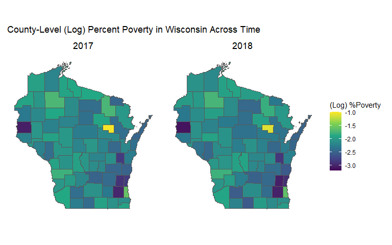

```r
p18 <- ggplot(wi_w.sf) +
    geom_sf(aes(fill = logpov_2018)) +
    scale_fill_viridis_c(limits = c(-3.2, -1)) +
    coord_sf(datum = NA) +
    theme_minimal() +
    theme(plot.title=element_text(hjust = 0.5)) +
    labs(title = "2018", fill="(Log) %Poverty")

p17 <- ggplot(wi_w.sf) +
    geom_sf(aes(fill = logpov_2017)) +
    scale_fill_viridis_c(limits = c(-3.2, -1)) +
    coord_sf(datum = NA) +
    theme_minimal() +
    theme(plot.title=element_text(hjust = 0.5)) +
    labs(title = "2017", fill="(Log) %Poverty")


#patchwork the plots together
patch1 <- p17 + p18
patch1 +
    plot_annotation(title="County-Level (Log) Percent Poverty in Wisconsin Across Time") +
    plot_layout(guides = "collect")
```

### Create Neighbors

Creating the neighborhood structure and list of spatial weights is the same as above in *long* format.

```r
row.names(wi_w.sf) <- wi_w.sf$NAME
head(row.names(wi_w.sf))
```

```
## [1] "Adams County, Wisconsin"    "Ashland County, Wisconsin"
## [3] "Barron County, Wisconsin"   "Bayfield County, Wisconsin"
## [5] "Brown County, Wisconsin"    "Buffalo County, Wisconsin"
```

```r
wi_nb_w <- poly2nb(wi_w.sf, row.names=row.names(wi_w.sf))
str(head(wi_nb_w))
```

```
## List of 6
##  $ : int [1:6] 11 29 39 50 70 72
##  $ : int [1:4] 4 26 51 58
##  $ : int [1:8] 7 9 17 49 55 56 58 66
##  $ : int [1:4] 2 16 58 66
##  $ : int [1:6] 8 31 36 43 45 59
##  $ : int [1:3] 18 47 62
```

```r
listw_w <- nb2listw(wi_nb_w, style = "W")
class(listw_w)
```

```
## [1] "listw" "nb"
```

```r
str(head(listw_w$weights))
```

```
## List of 6
##  $ : num [1:6] 0.167 0.167 0.167 0.167 0.167 ...
##  $ : num [1:4] 0.25 0.25 0.25 0.25
##  $ : num [1:8] 0.125 0.125 0.125 0.125 0.125 0.125 0.125 0.125
##  $ : num [1:4] 0.25 0.25 0.25 0.25
##  $ : num [1:6] 0.167 0.167 0.167 0.167 0.167 ...
##  $ : num [1:3] 0.333 0.333 0.333
```

```r
county_geoms <- st_geometry(wi_w.sf)
cntrd <- st_centroid(county_geoms)
coords <- st_coordinates(cntrd)
head(coords)
```

```
##           X        Y
## 1 -89.77039 43.96953
## 2 -90.67794 46.31608
## 3 -91.84831 45.42368
## 4 -91.20079 46.52376
## 5 -88.00373 44.45294
## 6 -91.75445 44.37983
```

To be sure that our neighbors look the same, we can again plot the county geometries, centroids, and neighborhood:

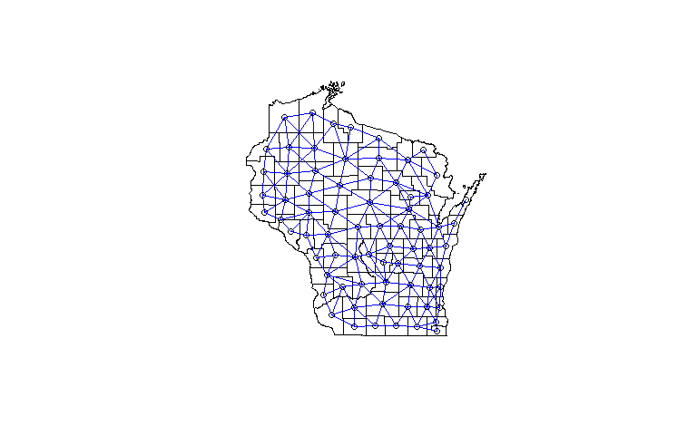

```r
plot(county_geoms)
plot(listw_w, coords, col="blue", add=TRUE)
```

### Using `strm`

The first argument is the model formula. Given that the data is now in *wide* format, we must manually enter the response and all of the explanatory variables and their lagged terms. The next argument is `id`, which we set to "NAME" as each observation is taken at the county-level. We then specify the name of the data set (`data=wi_w.sf`). We set the argument `listw=listw_w` to the row-standardized list of spatial weights. We set `time=2` because there are 2 time periods in the dataset. We set `wide=TRUE`, thereby specifying that the data is in *wide* format.

```r
formula2 <-as.formula(logpov_2018  ~feemp_prct_2017 + feemp_prct_2018 + logpov_2017)
out2 <- strm(formula2, id="NAME", data=wi_w.sf, listw= listw_w, time=2, wide=TRUE)
```

```
## The spatio-temporal regression model fitted:
```

```
## logpov_2018 ~ feemp_prct_2017 + feemp_prct_2018 + logpov_2017
```

```r
summary(out2)
```

```
##
## Call:spatialreg::errorsarlm(formula = modframe, listw = listw)
##
## Residuals:
##        Min         1Q     Median         3Q        Max
## -0.1164060 -0.0271688 -0.0052208  0.0303804  0.1135471
##
## Type: error
## Coefficients: (asymptotic standard errors)
##                  Estimate Std. Error z value  Pr(>|z|)
## (Intercept)      0.490040   0.194409  2.5207 0.0117132
## feemp_prct_2017  8.009277   2.792433  2.8682 0.0041281
## feemp_prct_2018 -9.122176   2.765474 -3.2986 0.0009717
## logpov_2017      0.992349   0.018244 54.3924 < 2.2e-16
##
## Lambda: -0.35546, LR test value: 2.9886, p-value: 0.08385
## Asymptotic standard error: 0.18981
##     z-value: -1.8727, p-value: 0.061103
## Wald statistic: 3.5072, p-value: 0.061103
##
## Log likelihood: 110.748 for error model
## ML residual variance (sigma squared): 0.0026359, (sigma: 0.051341)
## Number of observations: 72
## Number of parameters estimated: 6
## AIC: -209.5, (AIC for lm: -208.51)
```

Compare the output from `out$res` from the *long* format dataframe and `out2` from the *wide* format dataframe and see that they are the same!

```r
knitr::kable(tidy(out$res), digits=3, caption="Long Format Model")
```

Long Format Model

| term | estimate | std.error | statistic | p.value |
| --- | --- | --- | --- | --- |
| (Intercept) | 0.490 | 0.194 | 2.521 | 0.012 |
| feemp_prct | -9.122 | 2.765 | -3.299 | 0.001 |
| feemp_prct.Tlag1 | 8.009 | 2.792 | 2.868 | 0.004 |
| logpov.Tlag1 | 0.992 | 0.018 | 54.392 | 0.000 |
| lambda | -0.355 | 0.190 | -1.873 | 0.061 |

```r
knitr::kable(tidy(out2), digits= 3,caption="Wide Format Model")
```

Wide Format Model

| term | estimate | std.error | statistic | p.value |
| --- | --- | --- | --- | --- |
| (Intercept) | 0.490 | 0.194 | 2.521 | 0.012 |
| feemp_prct_2017 | 8.009 | 2.792 | 2.868 | 0.004 |
| feemp_prct_2018 | -9.122 | 2.765 | -3.299 | 0.001 |
| logpov_2017 | 0.992 | 0.018 | 54.392 | 0.000 |
| lambda | -0.355 | 0.190 | -1.873 | 0.061 |

# Working with `tidycensus`

In this example, we have provided the data used. However the data can be downloaded directly using the `tidycensus` R package. The code to download the data directly is below. To use `tidycensus`, you will need to request an API key [here](https://api.census.gov/data/key_signup.html).

```r
#load tidycensus
library(tidycensus)
options(tigris_use_cache = TRUE)
```

## Downloading Census Data Using `tidycensus`

From the `tidycensus` package, we use the `census_api_key()` function and specify `install=TRUE` so that the API key is stored in the local R environment. To access the variables we want from the American Community Survey. It should be noted that using tidycensus, we can also access the 1990, 2000, and 2010 decennial US Census data as well.

```r
census_api_key("YOUR API KEY HERE", install=TRUE)
```

(You may need to either restart your R session or run `readRenviron("~/.Renviron")` in your console to use the API key immediately.)

```r
vars <- load_variables(2018, "acs5", cache=TRUE)
years <- lst(2017,2018)
multi_year <- map(years,~ get_acs(geography = "county",
                                  variables = c("B17020_001","B17020_002","B23022_026","B23022_001"),
                                  state = "WI",
                                  year = .x,
                                  geometry = TRUE)) %>%
              map2(years, ~ mutate(.x, id = .y))

wi_raw <- reduce(multi_year, rbind)
```

For more examples of working with the `tidycensus` package, please see the vignettes for [basic usage](https://walker-data.com/tidycensus/articles/basic-usage.html) and working with [spatial data](https://walker-data.com/tidycensus/articles/spatial-data.html). Full `tidycensus` support can be found [here](https://walker-data.com/tidycensus/index.html).